# Predicting Customer Churn

March 29th, 2017

```r
library(caret)
library(ggplot2)
```

```r
# load data
act_activity <- read.csv("account_activity.csv")
cust_info <- read.csv("customer_info.csv")
new_cust <- read.csv("new_customers.csv")
```

# Inspect Data

Make sure that variables are formatted as they should be, and if not, adjust variable type accordingly.

```r
# inspect data stucture
str(act_activity)
```

```
'data.frame':   3373 obs. of  17 variables:
 $ Customer.ID   : Factor w/ 3333 levels "4bb41f7c73db02b",..: 2513 1889 2732 1091 855 2205 2305 2909 2186 2824 ...
 $ VMail_Message : int  25 26 0 0 0 0 24 0 0 37 ...
 $ Day_Mins      : num  265 162 243 299 167 ...
 $ Day_Calls     : int  110 123 114 71 113 98 88 79 97 84 ...
 $ Day_Charge    : num  45.1 27.5 41.4 50.9 28.3 ...
 $ Eve_Mins      : num  197.4 195.5 121.2 61.9 148.3 ...
 $ Eve_Calls     : int  99 103 110 88 122 101 108 94 80 111 ...
 $ Eve_Charge    : num  16.78 16.62 10.3 5.26 12.61 ...
 $ Night_Mins    : num  245 254 163 197 187 ...
 $ Night_Calls   : int  91 103 104 89 121 118 118 96 90 97 ...
 $ Night_Charge  : num  11.01 11.45 7.32 8.86 8.41 ...
 $ Intl_Mins     : num  10 13.7 12.2 6.6 10.1 6.3 7.5 7.1 8.7 11.2 ...
 $ total_Mins    : num  717 625 539 565 512 ...
 $ Intl_Calls    : int  3 3 5 7 3 6 7 6 4 5 ...
 $ Intl_Charge   : num  2.7 3.7 3.29 1.78 2.73 1.7 2.03 1.92 2.35 3.02 ...
 $ Total_Charge  : num  75.6 59.2 62.3 66.8 52.1 ...
 $ CustServ_Calls: int  1 1 0 2 3 0 3 0 1 0 ...
```

```r
# inspect data stucture
str(cust_info)
```

```
'data.frame':   3373 obs. of  7 variables:
 $ Customer.ID: Factor w/ 3333 levels "4bb41f7c73db02b",..: 2513 1889 2732 1091 855 2205 2305 2909 2186 2824 ...
 $ State      : Factor w/ 51 levels "AK","AL","AR",..: 17 36 32 36 37 2 20 25 19 50 ...
 $ Area_Code  : int  415 415 415 408 415 510 510 415 408 415 ...
 $ Phone      : Factor w/ 3333 levels "327-1058","327-1319",..: 1927 1576 1118 1708 111 2254 1048 81 292 118 ...
 $ Intl_Plan  : Factor w/ 2 levels "no","yes": 1 1 1 2 2 2 1 2 1 2 ...
 $ VMail_Plan : Factor w/ 2 levels "no","yes": 2 2 1 1 1 1 2 1 1 2 ...
 $ Churn      : int  0 0 0 0 0 0 0 0 0 0 ...
```

```r
# inspect data stucture
str(new_cust)
```

```
'data.frame':   1809 obs. of  23 variables:
 $ State         : Factor w/ 51 levels "AK","AL","AR",..: 17 36 32 36 37 2 20 25 19 50 ...
 $ Account_Length: int  128 107 137 84 75 118 121 147 117 141 ...
 $ Area_Code     : int  415 415 415 408 415 510 510 415 408 415 ...
 $ Phone         : Factor w/ 1809 levels "327-1319","327-3053",..: 1050 859 617 937 58 1227 583 40 172 63 ...
 $ Intl_Plan     : Factor w/ 2 levels "no","yes": 1 1 1 2 2 2 1 2 1 2 ...
 $ VMail_Plan    : Factor w/ 2 levels "no","yes": 2 2 1 1 1 1 2 1 1 2 ...
 $ VMail_Message : int  25 26 0 0 0 0 24 0 0 37 ...
 $ Day_Mins      : num  265 162 243 299 167 ...
 $ Day_Calls     : int  110 123 114 71 113 98 88 79 97 84 ...
 $ Day_Charge    : num  45.1 27.5 41.4 50.9 28.3 ...
 $ Eve_Mins      : num  197.4 195.5 121.2 61.9 148.3 ...
 $ Eve_Calls     : int  99 103 110 88 122 101 108 94 80 111 ...
 $ Eve_Charge    : num  16.78 16.62 10.3 5.26 12.61 ...
 $ Night_Mins    : num  245 254 163 197 187 ...
 $ Night_Calls   : int  91 103 104 89 121 118 118 96 90 97 ...
 $ Night_Charge  : num  11.01 11.45 7.32 8.86 8.41 ...
 $ Intl_Mins     : num  10 13.7 12.2 6.6 10.1 6.3 7.5 7.1 8.7 11.2 ...
 $ total_Mins    : num  717 625 539 565 512 ...
 $ Intl_Calls    : int  3 3 5 7 3 6 7 6 4 5 ...
 $ Intl_Charge   : num  2.7 3.7 3.29 1.78 2.73 1.7 2.03 1.92 2.35 3.02 ...
 $ Total_Charge  : num  75.6 59.2 62.3 66.8 52.1 ...
 $ CustServ_Calls: int  1 1 0 2 3 0 3 0 1 0 ...
 $ Churn         : logi  NA NA NA NA NA NA ...
```

```r
# fix variable types where necessary
cust_info$Churn <- as.factor(cust_info$Churn)
levels(cust_info$Churn) <- make.names(c("no", "yes"))
cust_info$State <- as.factor(cust_info$State)
cust_info$Area_Code <- as.factor(cust_info$Area_Code)
```

```r
# count the number of rows
nrow(act_activity)
```

```
[1] 3373
```

```r
# count the number of rows
nrow(cust_info)
```

```
[1] 3373
```

```r
# count the number of rows
nrow(new_cust)
```

```
[1] 1809
```

# Remove Duplicates

```r
# remove complete case duplicates
act_activity <- unique(act_activity)
cust_info <- unique(cust_info)
new_cust <- unique(new_cust)
```

After removing duplicates, count the number of rows again

```r
# count the number of rows
nrow(act_activity)
```

```
[1] 3333
```

```r
# count the number of rows
nrow(cust_info)
```

```
[1] 3333
```

```r
# count the number of rows
nrow(new_cust)
```

```
[1] 1809
```

# Feature Engineering

In the existing dataset, there is no variable for the total number of calls made per customer. Create a new variable the sums the number of day calls, evening calls, and night calls.

```r
# create total_calls cariables
act_activity$Total_Calls <- act_activity$Day_Calls + act_activity$Eve_Calls + act_activity$Night_Calls
```

# Merge Datasets

To include both account activity and customer information in the dataset used for predicting customer churn, we can join the datasets based on Customer ID.

```r
# merge account activity with customer information
df <- merge(act_activity, cust_info, by="Customer.ID")
```

# Partition Data

Before running a model, we will split the dataset into a training dataset and a test dataset. The training dataset will be used to build the model, and the test dataset will be used to evaluate the model.

```r
# create partition
set.seed(1234)
trainIndex <- createDataPartition(df$Churn,
                                  p = .7,
                                  list = FALSE,
                                  times = 1)
# put data into training and test
train_df <- df[ trainIndex,]
test_df  <- df[-trainIndex,]
```

We will inspect the proportion of churned customers in the training and test datasets to make sure they are similiar

```r
prop.table(table(train_df$Churn))
```

```
       no       yes
0.8547558 0.1452442
```

```r
prop.table(table(test_df$Churn))
```

```
       no       yes
0.8558559 0.1441441
```

# Fit Model to Training Data

```r
# set up control for cross-validation
ctrl <- trainControl(method = "repeatedcv",
                     repeats = 5,
                     classProbs = TRUE,
                     summaryFunction = twoClassSummary)
```

```r
# run bagged classification model using the training data
set.seed(1234)
tree_fit <- train(Churn ~ . -Customer.ID -Phone,
                  data = train_df,
                  method = "treebag",
                  nbagg = 50,
                  metric = "ROC",
                  preProc = c("center", "scale"),
                  trControl = ctrl)
```

```r
# show the results of the model
tree_fit
```

```
Bagged CART

2334 samples
  23 predictors
   2 classes: 'no', 'yes'

Pre-processing: centered (71), scaled (71)
Resampling: Cross-Validated (10 fold, repeated 5 times)
Summary of sample sizes: 2101, 2100, 2101, 2101, 2100, 2100, ...
Resampling results:

  ROC        Sens      Spec
  0.9214896  0.996692  0.8353654
```

```r
# fit model to training data
tree_train <- predict(tree_fit, newdata = train_df, type = "prob")
```

```r
# set cut-off value for churn
tree_train$pred <- factor(ifelse(tree_train$yes >= 0.45, "yes", "no"))
tree_train <- cbind(tree_train, actual = train_df$Churn)
```

```r
# review performance of model on training data
confusionMatrix(data = tree_train$pred, reference = tree_train$actual, positive = 'yes')
```

```
Confusion Matrix and Statistics

          Reference
Prediction   no  yes
       no  1995    0
       yes    0  339

               Accuracy : 1
                 95% CI : (0.9984, 1)
    No Information Rate : 0.8548
    P-Value [Acc > NIR] : < 2.2e-16

                  Kappa : 1
 Mcnemar's Test P-Value : NA

            Sensitivity : 1.0000
            Specificity : 1.0000
         Pos Pred Value : 1.0000
         Neg Pred Value : 1.0000
             Prevalence : 0.1452
         Detection Rate : 0.1452
   Detection Prevalence : 0.1452
      Balanced Accuracy : 1.0000

       'Positive' Class : yes
```

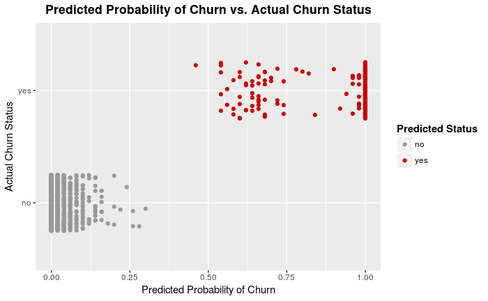

```r
# plot the posterior probability vs actual
ggplot(data = tree_train) +
  geom_point(mapping = aes(x = yes, y = actual, color = pred), position = position_jitter(w = 0, h = 0.25)) +
  ggtitle("Predicted Probability of Churn vs. Actual Churn Status") +
  theme(plot.title = element_text(lineheight=.8, face="bold", hjust = 0.5), ) +
  labs(x = "Predicted Probability of Churn", y = "Actual Churn Status") +
  theme(legend.title = element_text(face="bold"), legend.position = "right") +
  scale_color_manual(name = "Predicted Status", values = c("#999999", "#CC0000"))
```

# Fit Model to Test Data

```r
# fit model to test data
tree_test <- predict(tree_fit, newdata = test_df, type = "prob")
```

```r
# set cut-off value for churn
tree_test$pred <- factor(ifelse(tree_test$yes >= .45, "yes", "no"))
tree_test <- cbind(tree_test, actual = test_df$Churn)
```

```r
# review performance of model on test data
confusionMatrix(data = tree_test$pred, reference = tree_test$actual, positive = 'yes')
```

```
Confusion Matrix and Statistics

          Reference
Prediction  no yes
       no  849  19
       yes   6 125

               Accuracy : 0.975
                 95% CI : (0.9633, 0.9837)
    No Information Rate : 0.8559
    P-Value [Acc > NIR] : <2e-16

                  Kappa : 0.8946
 Mcnemar's Test P-Value : 0.0164

            Sensitivity : 0.8681
            Specificity : 0.9930
         Pos Pred Value : 0.9542
         Neg Pred Value : 0.9781
             Prevalence : 0.1441
         Detection Rate : 0.1251
   Detection Prevalence : 0.1311
      Balanced Accuracy : 0.9305

       'Positive' Class : yes
```

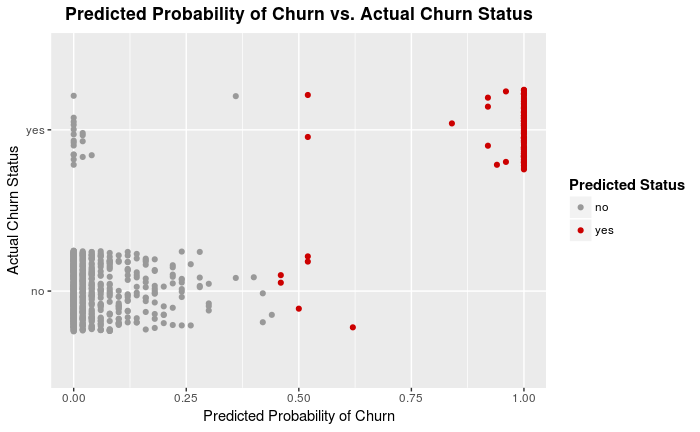

```r
# plot the posterior probability vs actual
ggplot(data = tree_test) +
  geom_point(mapping = aes(x = yes, y = actual, color = pred), position = position_jitter(w = 0, h = 0.25)) +
  ggtitle("Predicted Probability of Churn vs. Actual Churn Status") +
  theme(plot.title = element_text(lineheight=.8, face="bold", hjust = 0.5), ) +
  labs(x = "Predicted Probability of Churn", y = "Actual Churn Status") +
  theme(legend.title = element_text(face="bold"), legend.position = "right") +
  scale_color_manual(name = "Predicted Status", values = c("#999999", "#CC0000"))
```

# Identify Variable Importance

Variable importance measures the amount of decrease in accuracy of the model when each variable is removed from the model.

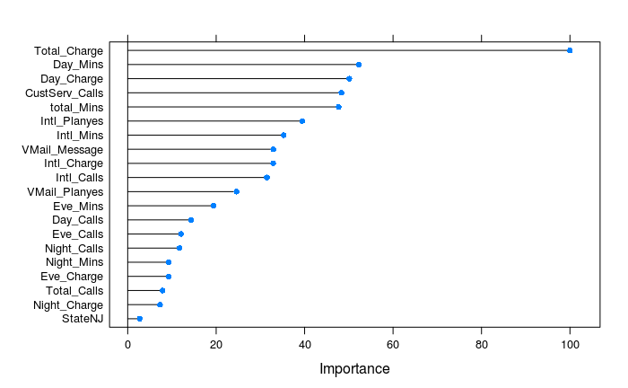

```r
# plot variable importance
plot(varImp(tree_fit), top=20)
```